# Light Bulb Classification Model Using Multi-Criteria Analysis in R

Gari Jerez

2026-04-01

## 1. Introduction

The documented results were carried out based on the anomalies and discrepancies detected in the consultancy, related to the classification of light bulb varieties in the price survey database.

Structural anomalies associated with:

- Incorrect ungrouping of varieties.
- Atypical differences in the price ranges collected.
- The non-coincidence of brands, technical characteristics and assigned variety.
- Presence of price ranges that do not correspond to the expected behavior of the declared variety.

In particular, cases were identified where the brand and technical characteristics of the product were not consistent with the category in which it was registered. That is to say, if a ‘Coral’ brand light bulb whose price is 35 pesos is in the ‘low consumption’ variety, it does not correspond to said variety since the ‘Coral’ brand corresponds to the incandescent variety due to several characteristics:

- Yellow light
- Powers of 100 Watts
- Filament structure

During the development of the analysis, several decision criteria were established conservatively that made it possible to identify the records whose evidence justified the reason for being reclassified.

This document details in a summarized and technical way the entire process carried out to obtain the desired results, constituting added value both for the validation process, as well as the collection of prices in the field.

## 2. Results

### 2.1 Clean table with selected variables

|  | tipo_origen | MARCA | PRECIO | OBSERVACION | MARCA_CORREGIDA |
| --- | --- | --- | --- | --- | --- |
| 1 | Bajo consumo | LIGHT PLUS | 50 | 26 W FILAMENTOS |  |
| 2 | Bajo consumo | RAYOVAC | 85 | 5W |  |
| 3 | Bajo consumo | PRICE CHOICE | 95 | 15 W | PRICE CHOICE |
| 4 | Bajo consumo | DOMUS | 80 |  | DOMUS |
| 5 | Bajo consumo | ACE | 135.95 | 25W | ACE |
| 6 | Bajo consumo | EURO LAMP | 99 | 30 WATTS, BAJO CONSUMO | EUROLAMP |
| 7 | Bajo consumo | BES VAULE | 216.59 | 24wtts-14180 | BEST VALUE |
| 8 | Bajo consumo | VOLTECK | 69 |  | VOLTECK |
| 9 | Bajo consumo | CORAL | 38.64 | COD:FG000327 | CORAL |
| 10 | Bajo consumo | CORAL | 75 | 25W | CORAL |

[output cut: 1439 more lines]

### 2.2 Exploratory analysis and detection of outliers

### 2.2.1 Statistical table by variety

|  | tipo_origen | Total | Mediana | Q1 | Q3 | IQR |
| --- | --- | --- | --- | --- | --- | --- |
| 1 | Bajo consumo | 327 | 0.1938552747633692 | -0.05377981842588391 | 0.4414903679526223 | 0.4952701863785062 |
| 2 | Incandescente | 621 | -0.6315950358674746 | -0.7141400669305589 | -0.6315950358674746 | 0.0825450310630843 |
| 3 | LED 0–10W | 297 | 0.2764003058264536 | 0.02876521263720046 | 0.606580430078791 | 0.5778152174415906 |
| 4 | LED 11W+ | 162 | 0.4414903679526223 | 0.1113102437002848 | 1.068832604032064 | 0.9575223603317788 |

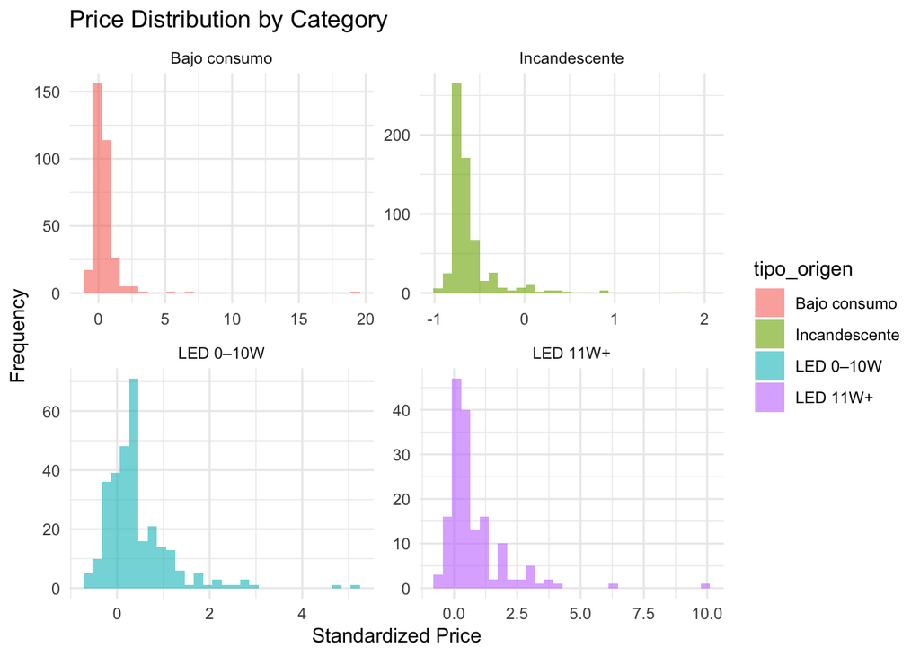

Figure 1. Price Distribution by Product Category

### 2.2.3 Atypical values according to their variety

|  | tipo_origen | Total | Outliers | Porcentaje |
| --- | --- | --- | --- | --- |
| 1 | Incandescente | 621 | 113 | 18.2% |
| 2 | Bajo consumo | 327 | 30 | 9.17% |
| 3 | LED 0–10W | 297 | 18 | 6.06% |
| 4 | LED 11W+ | 162 | 13 | 8.02% |

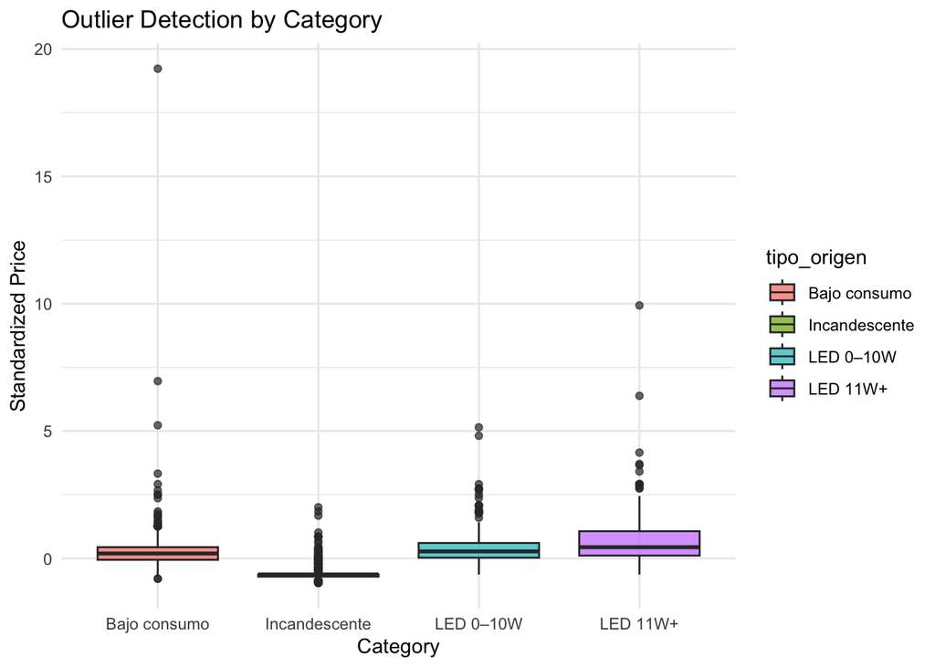

Figure 2. Outlier Detection by Category

### 3. Construction of the classification model

#### 3.1 Correction of brands

It was necessary to make corrections to the sample marks for standardization with the aim of unifying spelling variations and ensuring consistency in the analysis by manufacturer.

|  | MARCA_CORREGIDA | n |
| --- | --- | --- |
| 1 | CORAL | 467 |
| 2 |  | 342 |
| 3 | DOMUS | 67 |
| 4 | INLEC | 43 |
| 5 | ELEKTRA | 31 |
| 6 | BRAVO | 30 |
| 7 | FLY EAGLE | 30 |
| 8 | ILUMIA | 27 |
| 9 | YACO | 26 |
| 10 | TRIVO LUX | 22 |

[output cut: 54 more lines]

#### 3.2 Specific segmentation of Incandescents out of range

```
## # A tibble: 4 × 4
##   tipo_origen   total outliers porcentaje
##   <chr>         <int>    <dbl>      <dbl>
## 1 Incandescente   621      113      18.2
## 2 Bajo consumo    327       30       9.17
## 3 LED 11W+        162       13       8.02
## 4 LED 0–10W       297       18       6.06
```

```
## # A tibble: 1 × 1
##   mediana_led
##         <dbl>
## 1       0.359
```

|  | MARCA_CORREGIDA | PRECIO | limite_inferior | limite_superior |
| --- | --- | --- | --- | --- |
| 1 | CORAL | -0.4665049737413058 | -0.8379576135251854 | -0.5077774892728482 |
| 2 | CORAL | -0.3839599426782214 | -0.8379576135251854 | -0.5077774892728482 |
| 3 | CORAL | -0.05377981842588391 | -0.8379576135251854 | -0.5077774892728482 |
| 4 | BEST VALUE | -0.4878015917555815 | -0.8379576135251854 | -0.5077774892728482 |
| 5 | VOLTECK | -0.03727081221326704 | -0.8379576135251854 | -0.5077774892728482 |
| 6 |  | -0.05377981842588391 | -0.8379576135251854 | -0.5077774892728482 |
| 7 | YACO | -0.05377981842588391 | -0.8379576135251854 | -0.5077774892728482 |
| 8 | CORAL | -0.05377981842588391 | -0.8379576135251854 | -0.5077774892728482 |
| 9 | CORAL | 0.2764003058264536 | -0.8379576135251854 | -0.5077774892728482 |
| 10 | TITAN | 0.4414903679526223 | -0.8379576135251854 | -0.5077774892728482 |

[output cut: 103 more lines]

#### 3.3 Determination of dominant variety by brand

By segmenting the data by sample prices, a comparison was made by price proximity in which it is observed that certain brands present a high unique concentration of variety, after estimating the relative proportion

Of brands according to their origin. which constitutes a robust empirical criterion for validating reclassification processes.

|  | MARCA_CORREGIDA | bombillo_dominante | prop |
| --- | --- | --- | --- |
| 1 | 3 UNION | Incandescente | 1 |
| 2 | ACE | LED 0–10W | 0.3846153846153846 |
| 3 | AMÉRICA | Incandescente | 0.6153846153846154 |
| 4 | ANGEL LIGHT | LED 0–10W | 0.6666666666666666 |
| 5 | BEELIGHT | Incandescente | 0.6666666666666666 |
| 6 | BEST VALUE | Incandescente | 0.6666666666666666 |
| 7 | BIA | Bajo consumo | 0.75 |
| 8 | BRAVO | LED 0–10W | 0.7666666666666667 |
| 9 | CHIYODA | Bajo consumo | 0.5 |
| 10 | CONSUEG LIGHT | Incandescente | 1 |

[output cut: 54 more lines]

#### 3.4 Technological ambiguity and overlap

While the model was being developed, it was observed that there is an area where LED and low consumption (CFL) lamps overlap, especially between 9 and 23W. In that range, both can have very similar powers and similar prices, which makes it difficult to differentiate them if you only look at one variable.

This coincidence generates a certain ambiguity in the classification. For this reason, a more complete approach was chosen: a multi-criteria system that combines different elements, such as power, textual information, behavior by brand and consistency in prices.

### 3.5 Extraction of (watts) from observation

Statistical summary of the quantities of watts extracted from observation:

```
##     Min.  1st Qu.   Median     Mean  3rd Qu.     Max.     NA's
##      1.0      9.0     12.0    934.1     24.0 303711.0      702
```

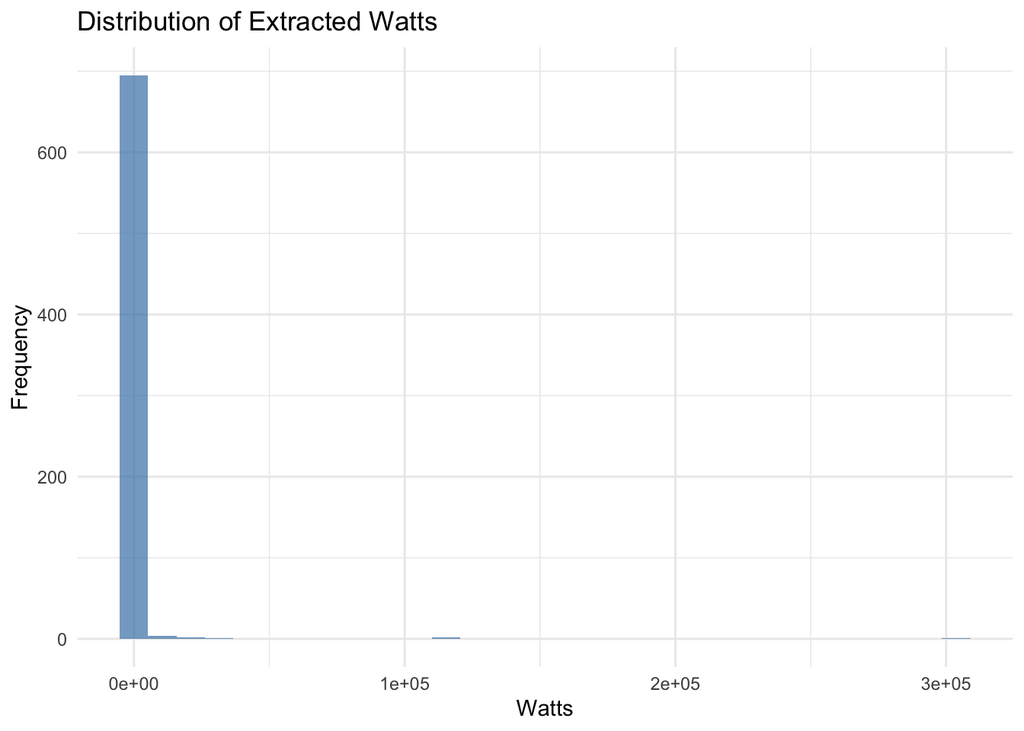

Figure 5. Distribution of Extracted Watts

Extracted cases:

|  | tipo_origen | MARCA_CORREGIDA | OBSERVACION | watts_extraido | PRECIO |
| --- | --- | --- | --- | --- | --- |
| 1 | Bajo consumo |  | 26 W FILAMENTOS | 26 | -0.3839599426782214 |
| 2 | Bajo consumo |  | 5W | 5 | 0.1938552747633692 |
| 3 | Bajo consumo | PRICE CHOICE | 15 W | 15 | 0.3589453368895379 |
| 4 | Bajo consumo | ACE | 25W | 25 | 1.034989141296199 |
| 5 | Bajo consumo | EUROLAMP | 30 WATTS, BAJO CONSUMO | 30 | 0.4249813617400054 |
| 6 | Bajo consumo | BEST VALUE | 24wtts-14180 | 24 | 2.366275402281624 |
| 7 | Bajo consumo | CORAL | COD:FG000327 | 327 | -0.5715022532535491 |
| 8 | Bajo consumo | CORAL | 25W | 25 | 0.02876521263720046 |
| 9 | Bajo consumo | MASTER LIGHT | FAN LIGHT 7W | 7 | 0.4414903679526223 |
| 10 | Bajo consumo |  | 7 WATT | 7 | 1.266940678583466 |

[output cut: 695 more lines]

Percentage of records containing identified watts:

```
## # A tibble: 1 × 3
##   Total Con_watts Porcentaje
##   <int>     <int>      <dbl>
## 1  1407       705       50.1
```

Percentage of records that contain identified watts Through the automatic extraction of power from the bulbs, it generates added value in the intermediate criterion analysis because it allows the specific watts of each registered trademark to be identified.

### 3.6 Preliminary technical classification

|  | tipo_origen | tipo_por_watts | tipo_texto | watts_extraido | PRECIO |
| --- | --- | --- | --- | --- | --- |
| 1 | Bajo consumo | Bajo consumo | Incandescente | 26 | -0.3839599426782214 |
| 2 | Bajo consumo | LED 0–10W |  | 5 | 0.1938552747633692 |
| 3 | Bajo consumo | Bajo consumo |  | 15 | 0.3589453368895379 |
| 4 | Bajo consumo |  |  |  | 0.1113102437002848 |
| 5 | Bajo consumo | Bajo consumo |  | 25 | 1.034989141296199 |
| 6 | Bajo consumo | Bajo consumo | Bajo consumo | 30 | 0.4249813617400054 |
| 7 | Bajo consumo | Bajo consumo |  | 24 | 2.366275402281624 |
| 8 | Bajo consumo |  |  |  | -0.0702888246385008 |
| 9 | Bajo consumo | Incandescente |  | 327 | -0.5715022532535491 |
| 10 | Bajo consumo | Bajo consumo |  | 25 | 0.02876521263720046 |

[output cut: 90 more lines]

### 3.7 Multicriteria Scoring System

A cumulative scoring system was implemented that assigns differentiated weights according to technical (power), semantic (observation text) and structural (consistency by brand) evidence. This scheme allows us to evaluate the relative strength of each possible classification.

|  | tipo_origen | watts_extraido | bombillo_dominante | prop | score_inc | score_cfl | score_led10 | score_led11 |
| --- | --- | --- | --- | --- | --- | --- | --- | --- |
| 1 | Bajo consumo | 26 | LED 0–10W | 0.3830409356725146 | 2 | 0 | 0 | 0 |
| 2 | Bajo consumo | 5 | LED 0–10W | 0.3830409356725146 | 0 | 0 | 3 | 0 |
| 3 | Bajo consumo | 15 | Bajo consumo | 0.75 | 0 | 2 | 0 | 2 |
| 4 | Bajo consumo |  | Bajo consumo | 0.6567164179104478 |  |  |  | 0 |
| 5 | Bajo consumo | 25 | LED 0–10W | 0.3846153846153846 | 0 | 0 | 0 | 2 |
| 6 | Bajo consumo | 30 | Bajo consumo | 0.5 | 0 | 0 | 0 | 0 |
| 7 | Bajo consumo | 24 | Incandescente | 0.6666666666666666 | 0 | 0 | 0 | 2 |
| 8 | Bajo consumo |  | Bajo consumo | 0.4545454545454545 |  |  |  | 0 |
| 9 | Bajo consumo | 327 | Incandescente | 0.9571734475374732 | 5 | 0 | 0 | 0 |
| 10 | Bajo consumo | 25 | Incandescente | 0.9571734475374732 | 2 | 0 | 0 | 2 |

[output cut: 1397 more lines]

### 3.8 Final Classification with Safety Margin

This allows reclassification when there is a sufficient difference between the best and the second best category.

|  | MARCA | tipo_origen | tipo_final | diferencia | watts_extraido | PRECIO | bombillo_dominante | prop | score_inc | score_cfl | score_led10 | score_led11 |
| --- | --- | --- | --- | --- | --- | --- | --- | --- | --- | --- | --- | --- |
| 1 | LIGHT PLUS | Bajo consumo | Incandescente | 2 | 26 | -0.3839599426782214 | LED 0–10W | 0.3830409356725146 | 2 | 0 | 0 | 0 |
| 2 | RAYOVAC | Bajo consumo | LED 0–10W | 3 | 5 | 0.1938552747633692 | LED 0–10W | 0.3830409356725146 | 0 | 0 | 3 | 0 |
| 3 | ACE | Bajo consumo | LED 11W+ | 2 | 25 | 1.034989141296199 | LED 0–10W | 0.3846153846153846 | 0 | 0 | 0 | 2 |
| 4 | EURO LAMP | Bajo consumo | Revisar | 0 | 30 | 0.4249813617400054 | Bajo consumo | 0.5 | 0 | 0 | 0 | 0 |
| 5 | BES VAULE | Bajo consumo | LED 11W+ | 2 | 24 | 2.366275402281624 | Incandescente | 0.6666666666666666 | 0 | 0 | 0 | 2 |
| 6 | CORAL | Bajo consumo | Incandescente | 5 | 327 | -0.5715022532535491 | Incandescente | 0.9571734475374732 | 5 | 0 | 0 | 0 |
| 7 | TOTAL 5 W/ | Bajo consumo | Revisar | 0 |  | 0.4249813617400054 | LED 0–10W | 0.3830409356725146 | 0 | 0 | 0 | 0 |
| 8 | BOMBILLA POKER | Bajo consumo | LED 0–10W | 3 | 7 | 1.266940678583466 | LED 0–10W | 0.3830409356725146 | 0 | 0 | 3 | 0 |
| 9 | TRIVOLUX | Bajo consumo | Incandescente | 3 | 50 | 0.1938552747633692 | Bajo consumo | 0.7272727272727273 | 3 | 0 | 0 | 0 |
| 10 | ELEKTRA | Bajo consumo | LED 11W+ | 2 | 25 | 0.8542155232680442 | Bajo consumo | 0.6129032258064516 | 0 | 0 | 0 | 2 |

[output cut: 231 more lines]

Model summary:

The multi-criteria scoring system ended up reclassifying 17.13% of the records analyzed (241 out of 1,407), which shows that there were several technical inconsistencies in the original classification.

In simple terms, this means that about one in six records had enough signals to warrant a review.

Anyway, the adjustment level is not that high. Rather, it suggests that the model acts quite cautiously, making changes only when the evidence really supports it and exceeds a minimum of safety.

|  | Total | Reclasificados | Porcentaje |
| --- | --- | --- | --- |
| 1 | 1407 | 241 | 17.13 |

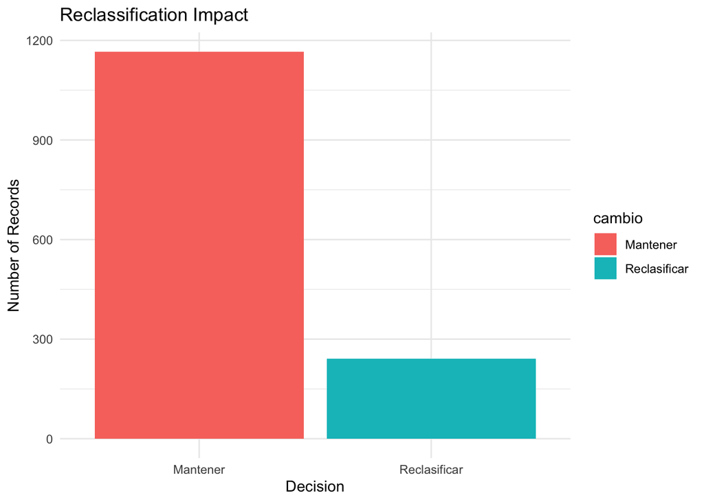

Figure 4. Model Reclassification Impact

### 3.9 Structural Analysis by Variety

The analysis by type of product makes it clear that reclassification does not occur evenly between all categories. The following table shows the adjustments made to where the problem of the article lies according to its variety:

|  | tipo_origen | Total | Reclasificados | Porcentaje |
| --- | --- | --- | --- | --- |
| 1 | Bajo consumo | 327 | 147 | 44.95 |
| 2 | LED 11W+ | 162 | 42 | 25.93 |
| 3 | LED 0–10W | 297 | 29 | 9.76 |
| 4 | Incandescente | 621 | 23 | 3.7 |

Most of the changes made are concentrated in **low consumption**, with **44.95 %** of the records reclassified. Which suggests that there is a technical overlap between the bulbs made of LED and low consumption coinciding in various ranges of watts, especially 9 and 23 watts.

In this context, the price alone is not enough to differentiate well between one and the other, since both can handle quite similar values in the market.

This kind of “gray zone” is what helps explain why the Low Consumption category has such a high reclassification rate.

In second place is **LED 11W+**, with **25.93 %**, suggesting that there may be some confusion in how the intermediate power ranges are being defined.

On the other hand, categories such as **LED 0–10W** **(9.76 %)** and **Incandescent** **(3.70 %)** remain much more stable. There seems to be quite a bit of consistency between power, price and available information.

Together, these results show that the model does not apply random changes, but rather focuses on the categories where there is the most technical ambiguity, avoiding touching those that are already consistent.

### 3.10 Transition Matrix between Original and Final Classification

The transition matrix makes it clear that reclassifications do not occur at random, but rather follow fairly coherent patterns from a technological point of view:

|  | tipo_origen | Bajo consumo | Incandescente | LED 0–10W | LED 11W+ | Revisar |
| --- | --- | --- | --- | --- | --- | --- |
| 1 | Bajo consumo | 180 | 26 | 39 | 56 | 26 |
| 2 | Incandescente | 1 | 598 | 6 | 2 | 14 |
| 3 | LED 0–10W | 1 | 10 | 268 | 2 | 16 |
| 4 | LED 11W+ | 0 | 12 | 21 | 120 | 9 |

For example, the “Low consumption” category shows a significant shift towards LED technologies, with 95 registers moving to LED 0–10W and LED 11W+. This fits with what had already been observed: there is an overlap in the intermediate power ranges (9–23W) that generates confusion.

On the other hand, the Incandescent category hardly moves. It maintains a 96.3% permanence, which indicates that it is quite solid and that the model is not forcing unnecessary changes.

Together, these results suggest that the multi-criteria system acts precisely, correcting specific inconsistencies without generally altering the rest of the classifications.

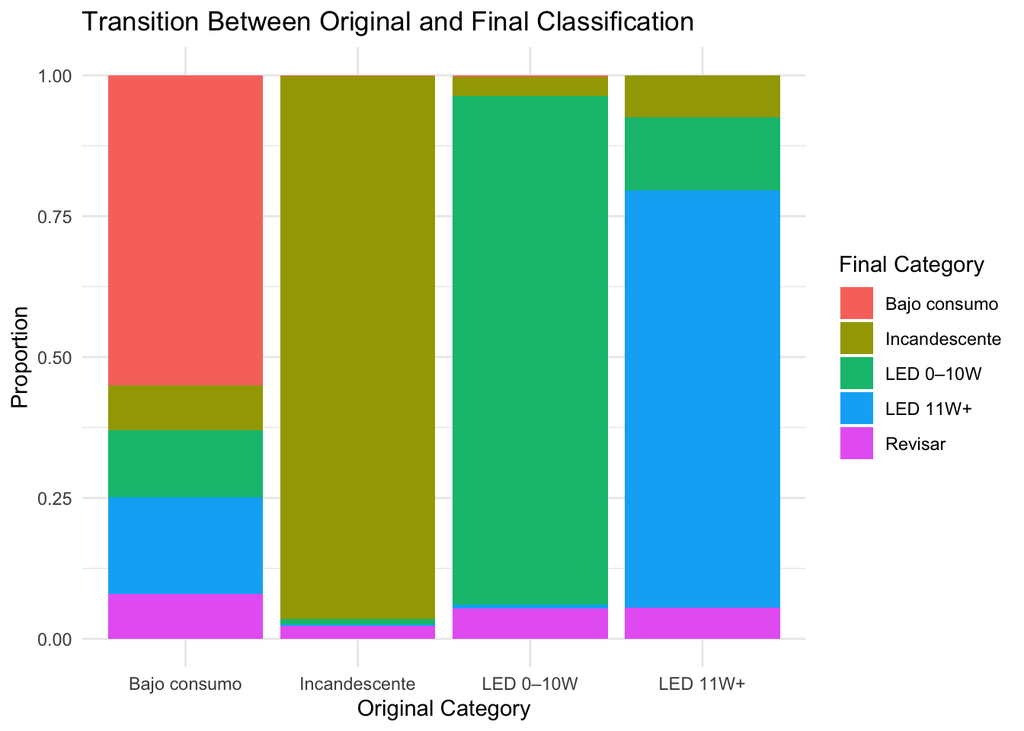

Figure 3. Transition Between Original and Final Classification

### 4. Economic Validation by Final Classification

Economic validation shows that there is consistency between technology type and price levels:

|  | tipo_final | Total | Mediana | Promedio | Q1 | Q3 |
| --- | --- | --- | --- | --- | --- | --- |
| 1 | LED 11W+ | 180 | 0.3919633493147717 | 0.663557596353591 | 0.02876521263720046 | 1.019305585394213 |
| 2 | LED 0–10W | 334 | 0.2764003058264536 | 0.3745359678463751 | 0.02876521263720046 | 0.4414903679526223 |
| 3 | Bajo consumo | 182 | 0.1938552747633692 | 0.4001180727132017 | -0.04965256687272969 | 0.4414903679526223 |
| 4 | Revisar | 65 | 0.1938552747633692 | 0.3187471766853707 | -0.1363248494889683 | 0.4414903679526223 |
| 5 | Incandescente | 646 | -0.6315950358674746 | -0.52333658873481 | -0.7141400669305589 | -0.5490500048043901 |

LED lamps appear with the highest price medians, followed by low consumption lamps, while incandescent lamps remain at the lowest level.

This order makes sense from a technological and market point of view, reinforcing the idea that the reclassification system is working consistently.

### 5. Conclusions

The multi-criteria scoring system ended up reclassifying 17.13% of the records analyzed (241 out of 1,407), which makes it clear that there were some technical inconsistencies in the original classification.

Most of these adjustments were concentrated in the “Low consumption” category, confirming that the problem was quite focused on areas where different technologies overlap.

At the same time, the model behaved prudently, applying changes only when the difference between categories was clear enough to exceed a minimum safety threshold.

Furthermore, by reviewing both the structure and prices, it is seen that the methodology improves overall consistency without generating unnecessary changes in categories that were already stable.